# ev02

Olivia Navarrete-A01654903

2022-05-05

**Parte Uno** https://youtu.be/bKp_lxxpJQc

**Parte dos**

**Trabajar con las secuencias de los coronavirus de otras especies que son similares a SARS-CoV-2, para tratar de explicar el fenómeno de zoonosis del virus. Incluye 20 especies reportadas. Puedes trabajar con variantes de SARS-CoV-2 de otros países.**

**Calcular la longitud de las secuencias**

```r
library (seqinr)
#Secuencia extraida
duck<-read.fasta("C:/Users/tete_/OneDrive/Escritorio/Oliv/Duck.fasta")
class(duck)
```

```
## [1] "list"
```

```r
str(duck)
```

```
## List of 1
##  $ JF705860.1: 'SeqFastadna' chr [1:27673] "a" "c" "t" "t" ...
##   ..- attr(*, "name")= chr "JF705860.1"
##   ..- attr(*, "Annot")= chr ">JF705860.1 Duck coronavirus isolate DK/CH/HN/ZZ2004, complete genome"
```

```r
#Longitud de la secuencia
length(duck[[1]])
```

```
## [1] 27673
```

```r
#Secuencia extraida
bat<-read.fasta("C:/Users/tete_/OneDrive/Escritorio/Oliv/Bat.fasta")
class(bat)
```

```
## [1] "list"
```

```r
str(bat)
```

```
## List of 1
##  $ EF065511.1: 'SeqFastadna' chr [1:30488] "g" "a" "t" "t" ...
##   ..- attr(*, "name")= chr "EF065511.1"
##   ..- attr(*, "Annot")= chr ">EF065511.1 Bat coronavirus HKU5-3, complete genome"
```

```r
#Longitud de la secuencia
length(bat[[1]])
```

```
## [1] 30488
```

```r
#Secuencia extraida
bt<-read.fasta("C:/Users/tete_/OneDrive/Escritorio/Oliv/BtTp-Beta.fasta")
class(bt)
```

```
## [1] "list"
```

```r
str(bt)
```

```
## List of 1
##  $ KJ473822.1: 'SeqFastadna' chr [1:30247] "t" "t" "t" "t" ...
##   ..- attr(*, "name")= chr "KJ473822.1"
##   ..- attr(*, "Annot")= chr ">KJ473822.1 BtTp-BetaCoV/GX2012, complete genome"
```

```r
#Longitud de la secuencia
length(bt[[1]])
```

```
## [1] 30247
```

```r
#Secuencia extraida
pipis<-read.fasta("C:/Users/tete_/OneDrive/Escritorio/Oliv/Pipis.fasta")
class(pipis)
```

```
## [1] "list"
```

```r
str(pipis)
```

```
## List of 1
##  $ MN611520.1: 'SeqFastadna' chr [1:30511] "c" "t" "a" "g" ...
##   ..- attr(*, "name")= chr "MN611520.1"
##   ..- attr(*, "Annot")= chr ">MN611520.1 Pipistrellus abramus bat coronavirus HKU5-related isolate BY140568, complete genome"
```

```r
#Longitud de la secuencia
length(pipis[[1]])
```

```
## [1] 30511
```

```r
#Secuencia extraida
rabbit<-read.fasta("C:/Users/tete_/OneDrive/Escritorio/Oliv/Rabbit.fasta")
class(rabbit)
```

```
## [1] "list"
```

```r
str(rabbit)
```

```
## List of 1
##  $ JN874560.1: 'SeqFastadna' chr [1:31116] "g" "a" "t" "t" ...
##   ..- attr(*, "name")= chr "JN874560.1"
##   ..- attr(*, "Annot")= chr ">JN874560.1 Rabbit coronavirus HKU14 strain HKU14-3, complete genome"
```

```r
#Longitud de la secuencia
length(rabbit[[1]])
```

```
## [1] 31116
```

```r
#Secuencia extraida
canine<-read.fasta("C:/Users/tete_/OneDrive/Escritorio/Oliv/Canine.fasta")
class(canine)
```

```
## [1] "list"
```

```r
str(canine)
```

```
## List of 1
##  $ KX432213.1: 'SeqFastadna' chr [1:30868] "a" "a" "c" "t" ...
##   ..- attr(*, "name")= chr "KX432213.1"
##   ..- attr(*, "Annot")= chr ">KX432213.1 Canine respiratory coronavirus strain BJ232, complete genome"
```

```r
#Longitud de la secuencia
length(canine[[1]])
```

```
## [1] 30868
```

```r
#Secuencia extraida
porcine<-read.fasta("C:/Users/tete_/OneDrive/Escritorio/Oliv/Porcine.fasta")
class(porcine)
```

```
## [1] "list"
```

```r
str(porcine)
```

```
## List of 1
##  $ KY994645.1: 'SeqFastadna' chr [1:30684] "g" "a" "t" "t" ...
##   ..- attr(*, "name")= chr "KY994645.1"
##   ..- attr(*, "Annot")= chr ">KY994645.1 Porcine hemagglutinating encephalomyelitis virus strain JL/2008, complete genome"
```

```r
#Longitud de la secuencia
length(porcine[[1]])
```

```
## [1] 30684
```

```r
#Secuencia extraida
rattus<-read.fasta("C:/Users/tete_/OneDrive/Escritorio/Oliv/Rattus.fasta")
class(rattus)
```

```
## [1] "list"
```

```r
str(rattus)
```

```
## List of 1
##  $ KM349742.1: 'SeqFastadna' chr [1:31249] "g" "a" "t" "a" ...
##   ..- attr(*, "name")= chr "KM349742.1"
##   ..- attr(*, "Annot")= chr ">KM349742.1 Betacoronavirus HKU24 strain HKU24-R05005I, complete genome"
```

```r
#Longitud de la secuencia
length(rattus[[1]])
```

```
## [1] 31249
```

```r
#Secuencia extraida
chicken<-read.fasta ("C:/Users/tete_/OneDrive/Escritorio/Oliv/Chicken.fasta")
class(chicken)
```

```
## [1] "list"
```

```r
str(chicken)
```

```
## List of 1
##  $ KX185057.1: 'SeqFastadna' chr [1:27802] "a" "c" "t" "g" ...
##   ..- attr(*, "name")= chr "KX185057.1"
##   ..- attr(*, "Annot")= chr ">KX185057.1 Infectious bronchitis virus strain ck/CH/LHLJ/95I, complete genome"
```

```r
#Longitud de la secuencia
length(chicken[[1]])
```

```
## [1] 27802
```

```r
#Secuencia extraida
tylonycteris<-read.fasta ("C:/Users/tete_/OneDrive/Escritorio/Oliv/Tylonycteris.fasta")
class(tylonycteris)
```

```
## [1] "list"
```

```r
str(tylonycteris)
```

```
## List of 1
##  $ KJ473822.1: 'SeqFastadna' chr [1:30247] "t" "t" "t" "t" ...
##   ..- attr(*, "name")= chr "KJ473822.1"
##   ..- attr(*, "Annot")= chr ">KJ473822.1 BtTp-BetaCoV/GX2012, complete genome"
```

```r
#Longitud de la secuencia
length(tylonycteris[[1]])
```

```
## [1] 30247
```

```r
#Secuencia extraida
myotis<-read.fasta("C:/Users/tete_/OneDrive/Escritorio/Oliv/Myotis.fasta")
class(myotis)
```

```
## [1] "list"
```

```r
str(myotis)
```

```
## List of 1
##  $ KV182965.1: 'SeqFastadna' chr [1:578] "g" "t" "t" "c" ...
##   ..- attr(*, "name")= chr "KV182965.1"
##   ..- attr(*, "Annot")= chr ">KV182965.1 Dorcoceras hygrometricum cultivar XS01 unplaced genomic scaffold scaffold201606, whole genome shotgun sequence"
```

```r
#Longitud de la secuencia
length(myotis[[1]])
```

```
## [1] 578
```

```r
#Secuencia extraida
vespertilio<-read.fasta("C:/Users/tete_/OneDrive/Escritorio/Oliv/Vespetilio.fasta")
class(vespertilio)
```

```
## [1] "list"
```

```r
str(vespertilio)
```

```
## List of 1
##  $ KJ473821.1: 'SeqFastadna' chr [1:30423] "g" "a" "t" "t" ...
##   ..- attr(*, "name")= chr "KJ473821.1"
##   ..- attr(*, "Annot")= chr ">KJ473821.1 BtVs-BetaCoV/SC2013, complete genome"
```

```r
#Longitud de la secuencia
length(vespertilio[[1]])
```

```
## [1] 30423
```

```r
#Secuencia extraida
enrinaceus<-read.fasta("C:/Users/tete_/OneDrive/Escritorio/Oliv/Enrinaceus.fasta")
class(enrinaceus)
```

```
## [1] "list"
```

```r
str(enrinaceus)
```

```
## List of 1
##  $ MK907287.1: 'SeqFastadna' chr [1:29951] "g" "a" "t" "t" ...
##   ..- attr(*, "name")= chr "MK907287.1"
##   ..- attr(*, "Annot")= chr ">MK907287.1 Erinaceus hedgehog coronavirus HKU31 strain Rs13, complete genome"
```

```r
#Longitud de la secuencia
length(enrinaceus[[1]])
```

```
## [1] 29951
```

```r
#Secuencia extraida
paguma<-read.fasta("C:/Users/tete_/OneDrive/Escritorio/Oliv/Paguna.fasta")
class(paguma)
```

```
## [1] "list"
```

```r
str(paguma)
```

```
## List of 1
##  $ AY515512.1: 'SeqFastadna' chr [1:29731] "g" "a" "a" "a" ...
##   ..- attr(*, "name")= chr "AY515512.1"
##   ..- attr(*, "Annot")= chr ">AY515512.1 SARS coronavirus HC/SZ/61/03, complete genome"
```

```r
#Longitud de la secuencia
length(paguma[[1]])
```

```
## [1] 29731
```

```r
#Secuencia extraida
yak<-read.fasta("C:/Users/tete_/OneDrive/Escritorio/Oliv/Yak.fasta")
class(yak)
```

```
## [1] "list"
```

```r
str(yak)
```

```
## List of 1
##  $ MH810163.1: 'SeqFastadna' chr [1:31032] "g" "a" "t" "t" ...
##   ..- attr(*, "name")= chr "MH810163.1"
##   ..- attr(*, "Annot")= chr ">MH810163.1 Yak coronavirus strain YAK/HY24/CH/2017, complete genome"
```

```r
#Longitud de la secuencia
length(yak[[1]])
```

```
## [1] 31032
```

```r
#Secuencia extraida
wigeon<-read.fasta("C:/Users/tete_/OneDrive/Escritorio/Oliv/Wigeon.fasta")
class(wigeon)
```

```
## [1] "list"
```

```r
str(wigeon)
```

```
## List of 1
##  $ NC_016995.1: 'SeqFastadna' chr [1:26227] "g" "t" "c" "a" ...
##   ..- attr(*, "name")= chr "NC_016995.1"
##   ..- attr(*, "Annot")= chr ">NC_016995.1 Wigeon coronavirus HKU20, complete genome"
```

```r
#Longitud de la secuencia
length(wigeon[[1]])
```

```
## [1] 26227
```

```r
#Secuencia extraida
rousettus<-read.fasta("C:/Users/tete_/OneDrive/Escritorio/Oliv/Rousettus.fasta")
class(rousettus)
```

```
## [1] "list"
```

```r
str(rousettus)
```

```
## List of 1
##  $ NC_030886.1: 'SeqFastadna' chr [1:30161] "g" "a" "a" "a" ...
##   ..- attr(*, "name")= chr "NC_030886.1"
##   ..- attr(*, "Annot")= chr ">NC_030886.1 Rousettus bat coronavirus isolate GCCDC1 356, complete genome"
```

```r
#Longitud de la secuencia
length(rousettus[[1]])
```

```
## [1] 30161
```

```r
#Secuencia extraida
aselliscus<-read.fasta("C:/Users/tete_/OneDrive/Escritorio/Oliv/Aselliscus.fasta")
class(aselliscus)
```

```
## [1] "list"
```

```r
str(aselliscus)
```

```
## List of 1
##  $ KY417142.1: 'SeqFastadna' chr [1:29725] "a" "t" "a" "t" ...
##   ..- attr(*, "name")= chr "KY417142.1"
##   ..- attr(*, "Annot")= chr ">KY417142.1 Bat SARS-like coronavirus isolate As6526, complete genome"
```

```r
#Longitud de la secuencia
length(aselliscus[[1]])
```

```
## [1] 29725
```

```r
#Secuencia extraida
lucheng<-read.fasta ("C:/Users/tete_/OneDrive/Escritorio/Oliv/Lucheng.fasta")
class(lucheng)
```

```
## [1] "list"
```

```r
str(lucheng)
```

```
## List of 1
##  $ KF294380.2: 'SeqFastadna' chr [1:28763] "a" "c" "t" "t" ...
##   ..- attr(*, "name")= chr "KF294380.2"
##   ..- attr(*, "Annot")= chr ">KF294380.2 Lucheng Rn rat coronavirus isolate Lucheng-19, complete genome"
```

```r
#Longitud de la secuencia
length(lucheng[[1]])
```

```
## [1] 28763
```

```r
#Secuencia extraida
apodemus<-read.fasta("C:/Users/tete_/OneDrive/Escritorio/Oliv/Apodemus.fasta")
class(apodemus)
```

```
## [1] "list"
```

```r
str(apodemus)
```

```
## List of 1
##  $ NC_034942.1: 'SeqFastadna' chr [1:133811] "t" "t" "a" "t" ...
##   ..- attr(*, "name")= chr "NC_034942.1"
##   ..- attr(*, "Annot")= chr ">NC_034942.1 Dacrycarpus imbricatus chloroplast DNA, complete genome"
```

```r
#Longitud de la secuencia
length(apodemus[[1]])
```

```
## [1] 133811
```

```r
animvir<-c(duck,bat,bt,pipis,rabbit,canine,porcine,rattus,chicken,tylonycteris)
animvir2<-c(myotis,vespertilio,enrinaceus,paguma,yak,wigeon,rousettus,aselliscus,lucheng,apodemus)
animnom1<-c("Duck","Bat","BtTp-Beta","Pipis","Rabbit","Canine","Porcine","Rattus","Chicken","Tylonycteris")
animnom2<-c("Myotis","Vespertilio","Enrinaceus","Paguna","Yak","Wigeon","Rousettus","Aselliscus","Lucheng","Apodemus")
```

**Crea una sola gráfica donde se comparen el número de bases de ADN que componen todas las variantes del virus.**

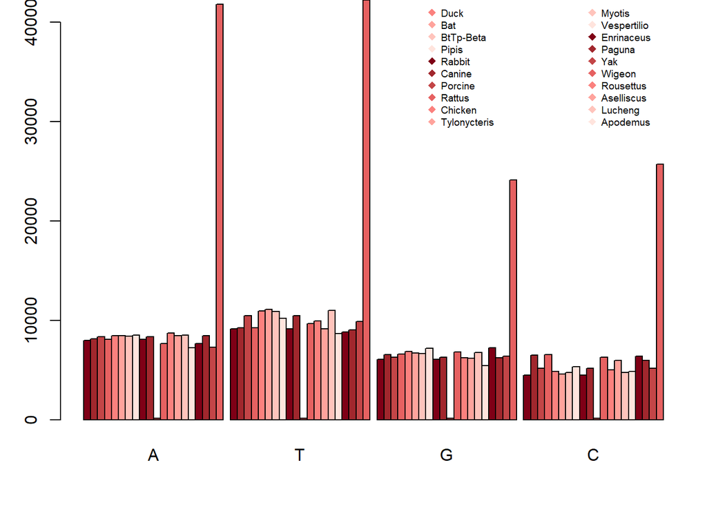

```r
cont <- function(seq){
  cont1A <-0
  cont1T <-0
  cont1C <-0
  cont1G <-0

  nl <- length(seq)

  for(i in seq){

    if(i=="A" || i=="a"){
      cont1A = cont1A + 1
    }
    else if(i=="T" || i=="t") {
      cont1T = cont1T + 1
    }
    else if(i=="C" || i=="c") {
      cont1C = cont1C + 1
    }
    else if(i=="G" || i=="g") {
      cont1G = cont1G + 1
    }
  }

  seq.x1<- c(cont1A,cont1T,cont1G, cont1C)
  return(seq.x1)
}

colorP<- c('#7f0016', '#a1272d', '#c34547', '#e66161', '#fb817e',  '#ffa39c','#ffc4bc', '#ffe4dd', '#7f0016', '#a1272d', '#c34547', '#e66161', '#fb817e', '#ffa39c', '#ffc4bc', '#ffe4dd', '#7f0016', '#a1272d', '#C34547', '#e66161')
colorP1<- c('#fb817e', '#ffa39c', '#ffc4bc', '#ffe4dd', '#7f0016',  '#a1272d','#c34547', '#e66161', '#fb817e', '#ffa39c')
colorP2<- c('#ffc4bc', '#ffe4dd', '#7f0016', '#a1272d', '#c34547', '#e66161', '#fb817e', '#ffa39c', '#ffc4bc', '#ffe4dd')


animnom1<-c("Duck","Bat","BtTp-Beta","Pipis","Rabbit","Canine","Porcine","Rattus","Chicken","Tylonycteris")
animnom2<- c("Myotis","Vespertilio","Enrinaceus","Paguna","Yak","Wigeon","Rousettus","Aselliscus","Lucheng","Apodemus")

funCov<- c(du<-sapply(duck, cont),bat1<-sapply(bat, cont),bt1<-sapply(bt, cont),pi<-sapply(pipis, cont),ra<-sapply(rabbit, cont),ca<-sapply(canine, cont),po<-sapply(porcine, cont),ra<-sapply(rattus, cont),chi<-sapply(chicken, cont),ty<-sapply(tylonycteris, cont),my<-sapply(myotis, cont),vesp<-sapply(vespertilio, cont),enri<-sapply(enrinaceus, cont),pag<-sapply(paguma, cont),yak<-sapply(yak, cont),wig<-sapply(wigeon, cont),rou<-sapply(rousettus, cont),ase<-sapply(aselliscus, cont),luc<-sapply(lucheng, cont),apod<-sapply(apodemus, cont))



par(mar=c(4,3,0,1))
virus<-barplot(matrix(c(funCov), nrow=20, byrow=T), beside=T,  col = colorP, names.arg= c("A","T","G", "C"))
legend("topright", legend = animnom1 ,
     col = colorP1 ,bty = "n", pch=18 , pt.cex = 1, cex = 0.6, horiz = FALSE, inset = c(0.3, 0.001))
legend("topright", legend = animnom2 ,
     col = colorP2 ,bty = "n", pch=18 , pt.cex = 1, cex = 0.6, horiz = FALSE, inset = c(0.05, 0.001))
```

**Agrega un análisis jerárquico global obtenido de las secuencias que se seleccionaron para estudiar**

```r
covid <- c(  "JF705860", "EF065511","KJ4738820", "MN611520","JN874560","KX432213","KY994645","KM349742","KX185057","KJ473822","KV182965", "KJ473821","MK907287","AY515512","MH810163","NC_016995","NC_030886","KY417142","KF294380","NC_034972")
```

```r
library(Biostrings)
library(seqinr)
library(adegenet)
library(ape)
library(ggtree)
library(DECIPHER)
library(viridis)
```

```r
library(ggplot2)
library(ggtree)
library(ggmsa)
virus_sequences <- read.GenBank(covid)
str(virus_sequences)
```

```
## List of 19
##  $ JF705860 : raw [1:27673] 88 28 18 18 ...
##  $ EF065511 : raw [1:30488] 48 88 18 18 ...
##  $ MN611520 : raw [1:30511] 28 18 88 48 ...
##  $ JN874560 : raw [1:31116] 48 88 18 18 ...
##  $ KX432213 : raw [1:30868] 88 88 28 18 ...
##  $ KY994645 : raw [1:30684] 48 88 18 18 ...
##  $ KM349742 : raw [1:31249] 48 88 18 88 ...
##  $ KX185057 : raw [1:27802] 88 28 18 48 ...
##  $ KJ473822 : raw [1:30247] 18 18 18 18 ...
##  $ KV182965 : raw [1:578] 48 18 18 28 ...
##  $ KJ473821 : raw [1:30423] 48 88 18 18 ...
##  $ MK907287 : raw [1:29951] 48 88 18 18 ...
##  $ AY515512 : raw [1:29731] 48 88 88 88 ...
##  $ MH810163 : raw [1:31032] 48 88 18 18 ...
##  $ NC_016995: raw [1:26227] 48 18 28 88 ...
##  $ NC_030886: raw [1:30161] 48 88 88 88 ...
##  $ KY417142 : raw [1:29725] 88 18 88 18 ...
##  $ KF294380 : raw [1:28763] 88 28 18 18 ...
##  $ NC_034972: raw [1:27682] 88 48 88 88 ...
##  - attr(*, "class")= chr "DNAbin"
##  - attr(*, "description")= chr [1:19] "JF705860.1 Duck coronavirus isolate DK/CH/HN/ZZ2004, complete genome" "EF065511.1 Bat coronavirus HKU5-3, complete genome" "MN611520.1 Pipistrellus abramus bat coronavirus HKU5-related isolate BY140568, complete genome" "JN874560.1 Rabbit coronavirus HKU14 s…
##  - attr(*, "species")= chr [1:19] "Duck_coronavirus" "Bat_coronavirus_HKU5-3" "Pipistrellus_abramus_bat_coronavirus_HKU5-related" "Rabbit_coronavirus_HKU14" ...
```

```r
attributes(virus_sequences)
```

```
## $names
##  [1] "JF705860"  "EF065511"  "MN611520"  "JN874560"  "KX432213"  "KY994645"
##  [7] "KM349742"  "KX185057"  "KJ473822"  "KV182965"  "KJ473821"  "MK907287"
## [13] "AY515512"  "MH810163"  "NC_016995" "NC_030886" "KY417142"  "KF294380"
## [19] "NC_034972"
##
## $class
## [1] "DNAbin"
##
## $description
##  [1] "JF705860.1 Duck coronavirus isolate DK/CH/HN/ZZ2004, complete genome"
##  [2] "EF065511.1 Bat coronavirus HKU5-3, complete genome"
##  [3] "MN611520.1 Pipistrellus abramus bat coronavirus HKU5-related isolate BY140568, complete genome"
##  [4] "JN874560.1 Rabbit coronavirus HKU14 strain HKU14-3, complete genome"
##  [5] "KX432213.1 Canine respiratory coronavirus strain BJ232, complete genome"
```

[output cut: 35 more lines]

```r
names(virus_sequences)
```

```
##  [1] "JF705860"  "EF065511"  "MN611520"  "JN874560"  "KX432213"  "KY994645"
##  [7] "KM349742"  "KX185057"  "KJ473822"  "KV182965"  "KJ473821"  "MK907287"
## [13] "AY515512"  "MH810163"  "NC_016995" "NC_030886" "KY417142"  "KF294380"
## [19] "NC_034972"
```

```r
attr(virus_sequences, "species")
```

```
##  [1] "Duck_coronavirus"
##  [2] "Bat_coronavirus_HKU5-3"
##  [3] "Pipistrellus_abramus_bat_coronavirus_HKU5-related"
##  [4] "Rabbit_coronavirus_HKU14"
##  [5] "Canine_respiratory_coronavirus"
##  [6] "Porcine_hemagglutinating_encephalomyelitis_virus"
##  [7] "Betacoronavirus_HKU24"
##  [8] "Infectious_bronchitis_virus"
##  [9] "BtTp-BetaCoV/GX2012"
## [10] "Dorcoceras_hygrometricum"
## [11] "BtVs-BetaCoV/SC2013"
## [12] "Erinaceus_hedgehog_coronavirus_HKU31"
## [13] "SARS_coronavirus_HC/SZ/61/03"
## [14] "Yak_coronavirus"
## [15] "Wigeon_coronavirus_HKU20"
## [16] "Rousettus_bat_coronavirus"
## [17] "Bat_SARS-like_coronavirus"
## [18] "Lucheng_Rn_rat_coronavirus"
## [19] "Coronavirus_AcCoV-JC34"
```

```r
write.dna(virus_sequences,
          file ="virus_seqs.fasta",
          format = "fasta",
          append = FALSE,
          nbcol = 6,
          colsep = " ",
          colw = 10)
virus_seq_not_align <- readDNAStringSet("virus_seqs.fasta", format = "fasta")
virus_seq_not_align <- OrientNucleotides(virus_seq_not_align)
```

```
## ========================================================================================================================================================================================================
##
## Time difference of 0.22 secs
```

```r
virus_seq_align <- AlignSeqs(virus_seq_not_align)
```

```
## Determining distance matrix based on shared 11-mers:
## ================================================================================
##
## Time difference of 2.82 secs
##
## Clustering into groups by similarity:
## ================================================================================
##
## Time difference of 0 secs
##
## Aligning Sequences:
## ================================================================================
##
## Time difference of 75.83 secs
##
## Iteration 1 of 2:
##
## Determining distance matrix based on alignment:
## ================================================================================
##
## Time difference of 0.02 secs
##
## Reclustering into groups by similarity:
## ================================================================================
##
## Time difference of 0 secs
##
## Realigning Sequences:
## ================================================================================
##
## Time difference of 0.01 secs
##
## Alignment converged - skipping remaining iteration.
##
## Refining the alignment:
## ================================================================================
##
## Time difference of 108.43 secs
```

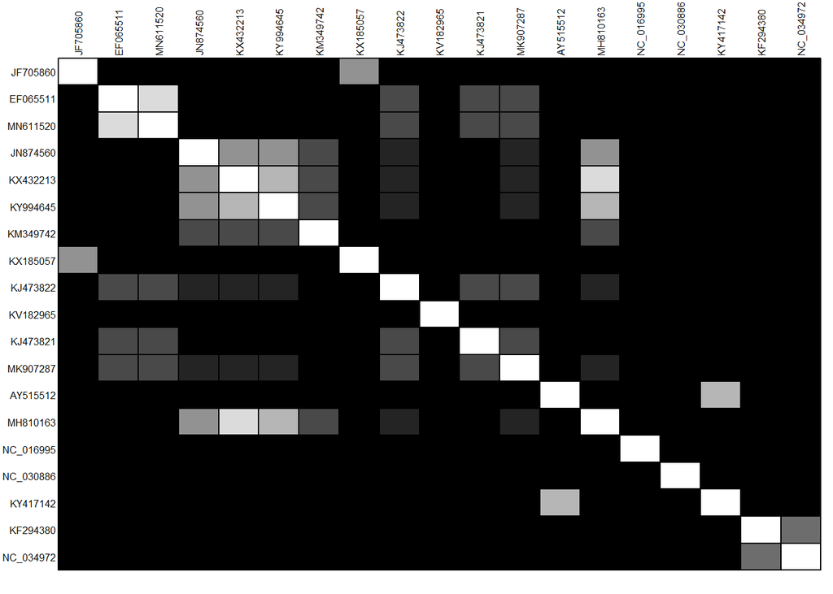

```r
BrowseSeqs(virus_seq_align, highlight=0)
writeXStringSet(virus_seq_align, file="virus_seq_align.fasta")
virus_aligned <- read.alignment("virus_seq_align.fasta", format = "fasta")
matriz_distancia <- dist.alignment(virus_aligned, matrix = "similarity")
temp <- as.data.frame(as.matrix(matriz_distancia))
table.paint(temp, cleg=0, clabel.row=.5, clabel.col=.5) + scale_color_viridis()
```

```r
virus_tree <- nj(matriz_distancia)
class(virus_tree)
```

```
## [1] "phylo"
```

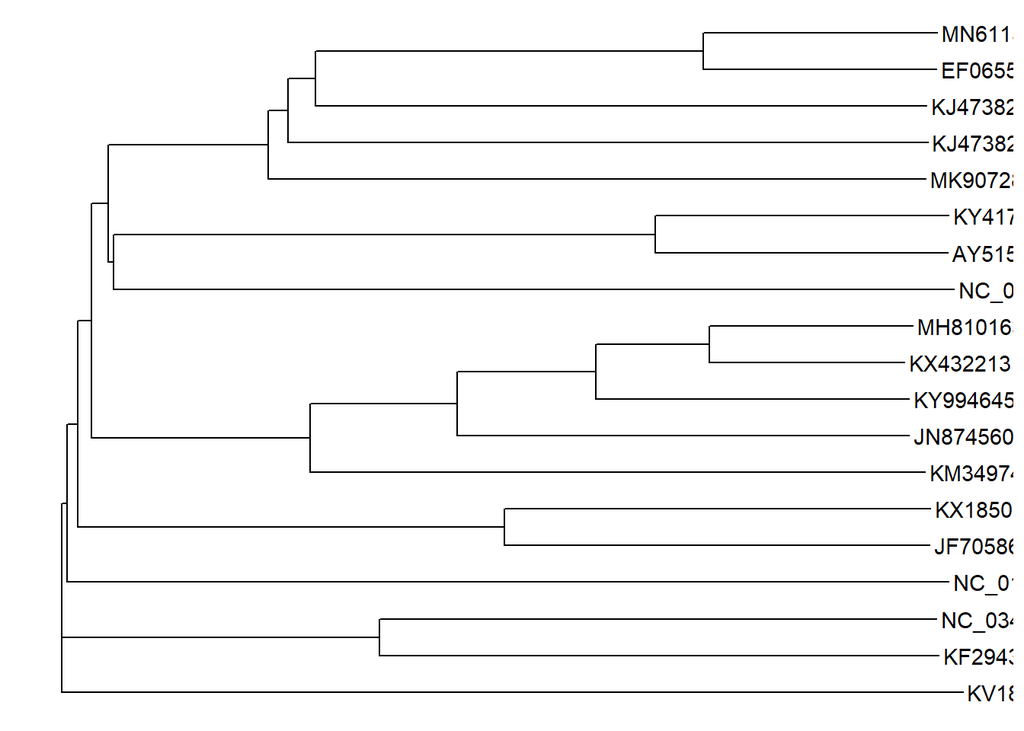

```r
virus_tree <- ladderize(virus_tree)
ggtree(virus_tree)+ geom_tiplab()
```

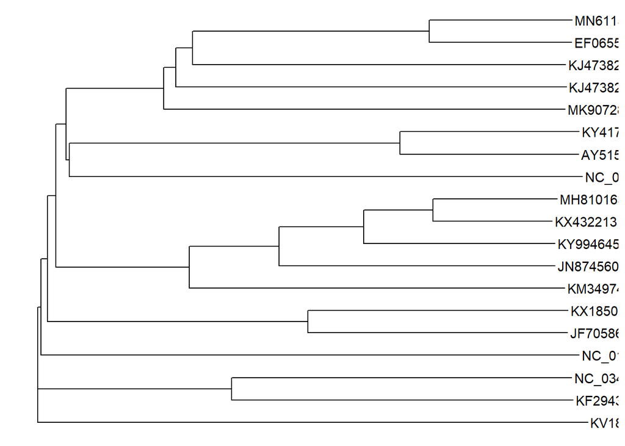

```r
ggtree(virus_tree)+geom_tiplab()
```

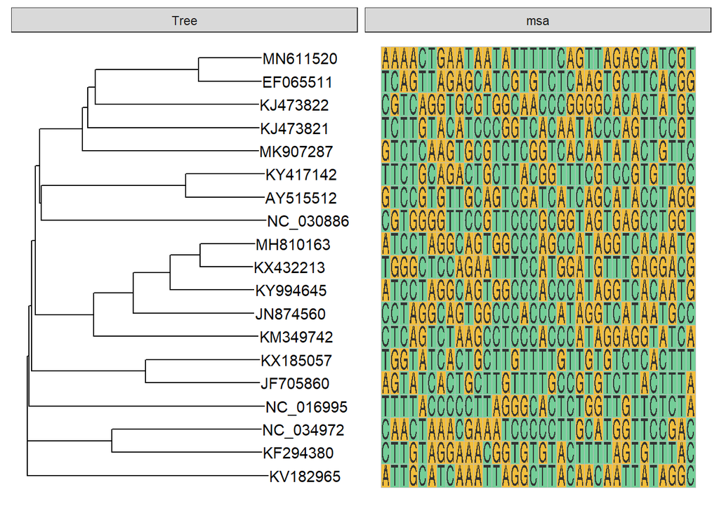

```r
plot_virus <- ggtree(virus_tree ) + geom_tiplab()
data = tidy_msa(virus_seq_not_align, 180, 213)
plot_virus + geom_facet(geom = geom_msa, data = data,  panel = 'msa', color = "Chemistry_AA") +
    xlim_tree(0.5)
```

**Referencias**

bdelrahman Z, Li M, Wang X. Comparative Review of SARS-CoV-2, SARS-CoV, MERS-CoV, and Influenza A Respiratory Viruses. Front Immunol. 2020 Sep 11;11:552909. doi: 10.3389/fimmu.2020.552909. PMID: 33013925; PMCID: PMC7516028.

Li, C., Yang, Y., & Ren, L. (2020). Genetic evolution analysis of 2019 novel coronavirus and coronavirus from other species. Infection, genetics and evolution : journal of molecular epidemiology and evolutionary genetics in infectious diseases, 82, 104285. https://doi.org/10.1016/j.meegid.2020.104285

Rabaan AA, Al-Ahmed SH, Haque S, Sah R, Tiwari R, Malik YS, Dhama K, Yatoo MI, Bonilla-Aldana DK, Rodriguez-Morales AJ. SARS-CoV-2, SARS-CoV, and MERS-COV: A comparative overview. Infez Med. 2020 Ahead Of Print Jun 1;28(2):174-184. PMID: 32275259. Chan T, Klaus J, Meli ML, Hofmann-Lehmann R. SARS-CoV-2 Infektionen bei Katzen, Hunden und anderen Tieren: Erkenntnisse zur Infektion und Daten aus der Schweiz [SARS-CoV-2 infections in cats, dogs, and other animal species: Findings on infection and data from Switzerland]. Schweiz Arch Tierheilkd. 2021 Dec;163(12):821-835. German. doi: 10.17236/sat00329. PMID: 34881715.

**Citar los paquetes en R** citation(packagename)

```r
citation("dplyr")
```

```
##
##
##   Wickham H, François R, Henry L, Müller K (2022). _dplyr: A Grammar of
##   Data Manipulation_. R package version 1.0.9,
##   <https://CRAN.R-project.org/package=dplyr>.
##
## A BibTeX entry for LaTeX users is
##
##   @Manual{,
##     title = {dplyr: A Grammar of Data Manipulation},
##     author = {Hadley Wickham and Romain François and Lionel Henry and Kirill Müller},
##     year = {2022},
##     note = {R package version 1.0.9},
##     url = {https://CRAN.R-project.org/package=dplyr},
##   }
```

```r
citation("Biostrings")
```

```
##
##
##   Pagès H, Aboyoun P, Gentleman R, DebRoy S (2022). _Biostrings:
##   Efficient manipulation of biological strings_. R package version
##   2.64.0, <https://bioconductor.org/packages/Biostrings>.
##
## A BibTeX entry for LaTeX users is
##
##   @Manual{,
##     title = {Biostrings: Efficient manipulation of biological strings},
##     author = {H. Pagès and P. Aboyoun and R. Gentleman and S. DebRoy},
##     year = {2022},
##     note = {R package version 2.64.0},
##     url = {https://bioconductor.org/packages/Biostrings},
##   }
##
## ATTENTION: This citation information has been auto-generated from the
## package DESCRIPTION file and may need manual editing, see
## 'help("citation")'.
```

```r
citation("seqinr")
```

```
##
##
##   Charif, D. and Lobry, J.R. (2007)
##
## A BibTeX entry for LaTeX users is
##
##   @InCollection{,
##     author = {D. Charif and J.R. Lobry},
##     title = {Seqin{R} 1.0-2: a contributed package to the {R} project for statistical computing devoted to biological sequences retrieval and analysis.},
##     booktitle = {Structural approaches to sequence evolution: Molecules, networks, populations},
##     year = {2007},
##     editor = {U. Bastolla and M. Porto and H.E. Roman and M. Vendruscolo},
##     series = {Biological and Medical Physics, Biomedical Engineering},
##     pages = {207-232},
##     address = {New York},
##     publisher = {Springer Verlag},
##     note = {{ISBN :} 978-3-540-35305-8},
##   }
```

```r
citation("adegenet")
```

```
##
##
##   Jombart, T. (2008) adegenet: a R package for the multivariate
##   analysis of genetic markers. Bioinformatics 24: 1403-1405. doi:
##   10.1093/bioinformatics/btn129
##
##   Jombart T. and Ahmed I. (2011) adegenet 1.3-1: new tools for the
##   analysis of genome-wide SNP data. Bioinformatics. doi:
##   10.1093/bioinformatics/btr521
##
## To see these entries in BibTeX format, use 'print(<citation>,
## bibtex=TRUE)', 'toBibtex(.)', or set
## 'options(citation.bibtex.max=999)'.
```

```r
citation("ape")
```

```
##
##
##   Paradis E. & Schliep K. 2019. ape 5.0: an environment for modern
##   phylogenetics and evolutionary analyses in R. Bioinformatics 35:
##   526-528.
##
## A BibTeX entry for LaTeX users is
##
##   @Article{,
##     title = {ape 5.0: an environment for modern phylogenetics and evolutionary analyses in {R}},
##     author = {E. Paradis and K. Schliep},
##     journal = {Bioinformatics},
##     year = {2019},
##     volume = {35},
##     pages = {526-528},
##   }
##
## As ape is evolving quickly, you may want to cite also its version
## number (found with 'library(help = ape)' or 'packageVersion("ape")').
```

```r
citation("phangorn")
```

```
##
## Use 2011 to cite phangorn in a publication; 2017 for plotting
## phylogenetic networks. As phangorn is evolving quickly, you may want to
## cite also its version number (phangorn 2.8.1).
##
##   Schliep K.P. 2011. phangorn: phylogenetic analysis in R.
##   Bioinformatics, 27(4) 592-593
##
##   Schliep, K., Potts, A. J., Morrison, D. A., Grimm, G. W. (2017),
##   Intertwining phylogenetic trees and networks. Methods in Ecology and
##   Evolution, 8: 1212--1220. doi: 10.1111/2041-210X.12760
##
## To see these entries in BibTeX format, use 'print(<citation>,
## bibtex=TRUE)', 'toBibtex(.)', or set
## 'options(citation.bibtex.max=999)'.
```

```r
citation("phytools")
```

```
##
##
##   Revell, L. J. (2012) phytools: An R package for phylogenetic
##   comparative biology (and other things). Methods Ecol. Evol. 3
##   217-223. doi:10.1111/j.2041-210X.2011.00169.x
##
## A BibTeX entry for LaTeX users is
##
##   @Article{,
##     title = {phytools: An R package for phylogenetic comparative biology (and other things).},
##     author = {Liam J. Revell},
##     journal = {Methods in Ecology and Evolution},
##     year = {2012},
##     volume = {3},
##     pages = {217-223},
##   }
##
## As phytools is continually evolving, you may want to cite its version
## number. Find it with 'help(package=phytools)'.
```

```r
citation("geiger")
```

```
##
##
## medusa
##
##   Alfaro Michael E, Francesco Santini, Chad Brock, Hugo Alamillo, Alex
##   Dornburg, Daniel L Rabosky, Giorgio Carnevale, and Luke J Harmon.
##   2009. Nine exceptional radiations plus high turnover explain species
##   diversity in jawed vertebrates. PNAS 106:13410-13414.
##
## auteur
##
##   Eastman Jonathan M, Michael E Alfaro, Paul Joyce, Andrew L Hipp, and
##   Luke J Harmon. 2011. A novel comparative method for identifying
##   shifts in the rate of character evolution on trees. Evolution
##   65:3578-3589.
##
## MECCA
##
##   Slater Graham J, Luke J Harmon, Daniel Wegmann, Paul Joyce, Liam J
##   Revell, and Michael E Alfaro. 2012. Fitting models of continuous
##   trait evolution to incompletely sampled comparative data using
##   approximate Bayesian computation. Evolution 66:752-762.
##
## geiger-orig
##
##   Harmon Luke J, Jason T Weir, Chad D Brock, Richard E Glor, and
##   Wendell Challenger. 2008. GEIGER: investigating evolutionary
##   radiations. Bioinformatics 24:129-131.
##
## geiger
##
##   Pennell Matthew W, Jonathan M Eastman, Graham J Slater, Joseph W
##   Brown, Josef C Uyeda, Richard G FitzJohn, Michael E Alfaro, and Luke
##   J Harmon. 2014. geiger v2.0: an expanded suite of methods for fitting
##   macroevolutionary models to phylogenetic trees. Bioinformatics
##   30:2216-2218.
##
## To see these entries in BibTeX format, use 'print(<citation>,
## bibtex=TRUE)', 'toBibtex(.)', or set
## 'options(citation.bibtex.max=999)'.
```

```r
citation("BiocManager")
```

```
##
##
##   Morgan M (2022). _BiocManager: Access the Bioconductor Project
##   Package Repository_. R package version 1.30.17,
##   <https://CRAN.R-project.org/package=BiocManager>.
##
## A BibTeX entry for LaTeX users is
##
##   @Manual{,
##     title = {BiocManager: Access the Bioconductor Project Package Repository},
##     author = {Martin Morgan},
##     year = {2022},
##     note = {R package version 1.30.17},
##     url = {https://CRAN.R-project.org/package=BiocManager},
##   }
```

```r
citation("ggtree")
```

```
##
##
##   Guangchuang Yu. Using ggtree to visualize data on tree-like
##   structures. Current Protocols in Bioinformatics, 2020, 69:e96. doi:
##   10.1002/cpbi.96
##
##   Guangchuang Yu, Tommy Tsan-Yuk Lam, Huachen Zhu, Yi Guan. Two methods
##   for mapping and visualizing associated data on phylogeny using
##   ggtree. Molecular Biology and Evolution 2018, 35(2):3041-3043. doi:
##   10.1093/molbev/msy194
##
##   Guangchuang Yu, David Smith, Huachen Zhu, Yi Guan, Tommy Tsan-Yuk
##   Lam. ggtree: an R package for visualization and annotation of
##   phylogenetic trees with their covariates and other associated data.
##   Methods in Ecology and Evolution 2017, 8(1):28-36.
##   doi:10.1111/2041-210X.12628
##
## To see these entries in BibTeX format, use 'print(<citation>,
## bibtex=TRUE)', 'toBibtex(.)', or set
## 'options(citation.bibtex.max=999)'.
```

```r
citation("DECIPHER")
```

```
##
##
##   Wright ES (2016). "Using DECIPHER v2.0 to Analyze Big Biological
##   Sequence Data in R." _The R Journal_, *8*(1), 352-359.
##
## A BibTeX entry for LaTeX users is
##
##   @Article{,
##     title = {Using DECIPHER v2.0 to Analyze Big Biological Sequence Data in R},
##     author = {Erik S. Wright},
##     journal = {The R Journal},
##     year = {2016},
##     volume = {8},
##     number = {1},
##     pages = {352-359},
##   }
```

```r
citation("viridis")
```

[output not shown]

```r
citation("ggplot2")
```

```
##
##
##   H. Wickham. ggplot2: Elegant Graphics for Data Analysis.
##   Springer-Verlag New York, 2016.
##
## A BibTeX entry for LaTeX users is
##
##   @Book{,
##     author = {Hadley Wickham},
##     title = {ggplot2: Elegant Graphics for Data Analysis},
##     publisher = {Springer-Verlag New York},
##     year = {2016},
##     isbn = {978-3-319-24277-4},
##     url = {https://ggplot2.tidyverse.org},
##   }
```